## Practical Machine Learning Report

#### Benjamin Phillips

[GitHub Repository](https://github.com/BenjaminPhillips22/Practical_Machine_Learning)

### Clean the data

```r
df1 <- read.csv("pml-training.csv")

dim(df1)
```

```
## [1] 19622   160
```

a lot of colums are mostly NAs. Let’s get rid of them

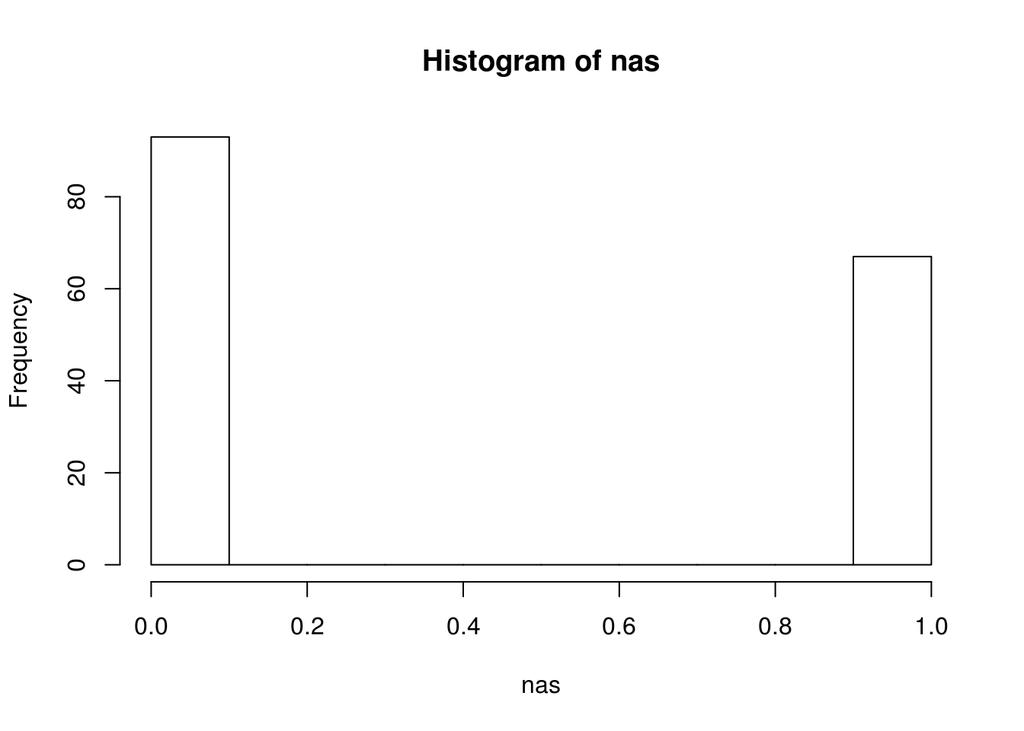

```r
func1 <- function(col){ sum(is.na(col))/length(col) }
nas <- sapply(X = df1, FUN = func1)
hist(nas)
```

```r
df1 <- df1[,nas<0.5]
dim(df1)
```

```
## [1] 19622    93
```

We’re down to 93 colums

let’s only use complete cases.

```r
sum(complete.cases(df1))==dim(df1)[1]
```

```
## [1] TRUE
```

No need to remove non complete cases.

We still have a few columns that are just empty

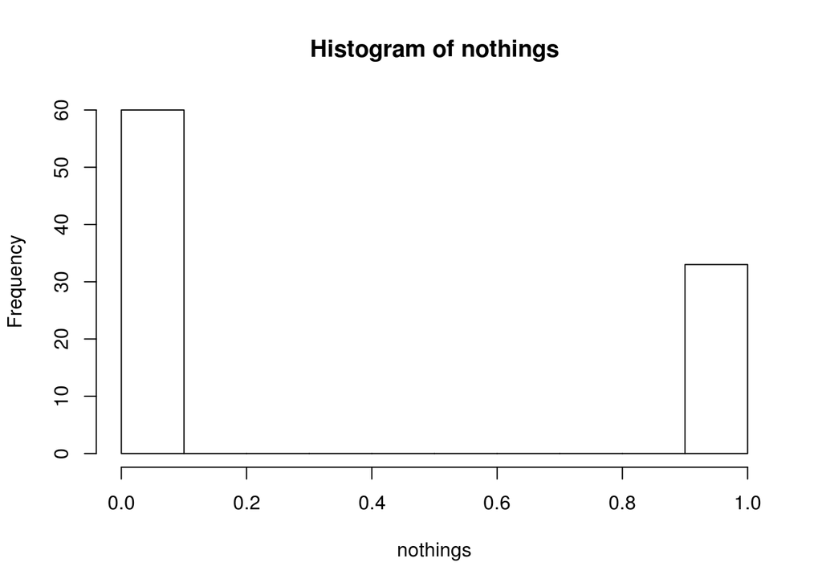

```r
func2 <- function(col){ sum(col=="")/length(col) }
nothings <- sapply(X = df1, FUN = func2)
hist(nothings)
```

```r
df1 <- df1[,nothings<0.5]
dim(df1)
```

```
## [1] 19622    60
```

Now we’re down to 60 colums

```r
classes <- sapply(df1, class)
table(classes)
```

```
## classes
##  factor integer numeric
##       4      29      27
```

The classe factor is what we will try to predict.

The timestamp and new_window data don’t have anything to do with the activity. It’s just when the data was downloaded to a computer.

```r
df1 <- df1[,-grep("window",names(df1))]

df1 <- df1[,-grep("timestamp",names(df1))]

dim(df1)
```

```
## [1] 19622    55
```

Down to 55 columns

df1 looks good. Let’s ship it

```
set.seed(9993)
inTrain <- createDataPartition(df1$classe, p=0.7, list = FALSE)
train <- df1[inTrain,]
test <- df1[-inTrain,]
```

Save it for later exploration and use.

```
write.csv(train, "clean_training_data.csv")
write.csv(test, "clean_test_data.csv")
```

### Explore the data

```r
library(ggplot2)
library(dplyr)
library(caret)
library(corrplot)
library(rpart.plot)
library(rattle)
```

Split it into training and validation

```r
df <- read.csv("clean_training_data.csv")

set.seed(1580003)
inTrain <- createDataPartition(df$classe, p=0.9, list = FALSE)
training <- df[inTrain,]
validation <- df[-inTrain,]
rm(df)
```

OK, finally! We can explore our training data

```r
dim(training)
```

```
## [1] 12366    56
```

```r
names(training)
```

```
##  [1] "X.1"                  "X"                    "user_name"
##  [4] "roll_belt"            "pitch_belt"           "yaw_belt"
##  [7] "total_accel_belt"     "gyros_belt_x"         "gyros_belt_y"
## [10] "gyros_belt_z"         "accel_belt_x"         "accel_belt_y"
## [13] "accel_belt_z"         "magnet_belt_x"        "magnet_belt_y"
## [16] "magnet_belt_z"        "roll_arm"             "pitch_arm"
## [19] "yaw_arm"              "total_accel_arm"      "gyros_arm_x"
## [22] "gyros_arm_y"          "gyros_arm_z"          "accel_arm_x"
## [25] "accel_arm_y"          "accel_arm_z"          "magnet_arm_x"
## [28] "magnet_arm_y"         "magnet_arm_z"         "roll_dumbbell"
## [31] "pitch_dumbbell"       "yaw_dumbbell"         "total_accel_dumbbell"
## [34] "gyros_dumbbell_x"     "gyros_dumbbell_y"     "gyros_dumbbell_z"
## [37] "accel_dumbbell_x"     "accel_dumbbell_y"     "accel_dumbbell_z"
## [40] "magnet_dumbbell_x"    "magnet_dumbbell_y"    "magnet_dumbbell_z"
## [43] "roll_forearm"         "pitch_forearm"        "yaw_forearm"
## [46] "total_accel_forearm"  "gyros_forearm_x"      "gyros_forearm_y"
## [49] "gyros_forearm_z"      "accel_forearm_x"      "accel_forearm_y"
## [52] "accel_forearm_z"      "magnet_forearm_x"     "magnet_forearm_y"
## [55] "magnet_forearm_z"     "classe"
```

```r
classes <- sapply(training, class)
table(classes)
```

```
## classes
##  factor integer numeric
##       2      27      27
```

```r
which(classes==c("factor"))
```

```
## user_name    classe
##         3        56
```

Correlations? (remove factor variables)

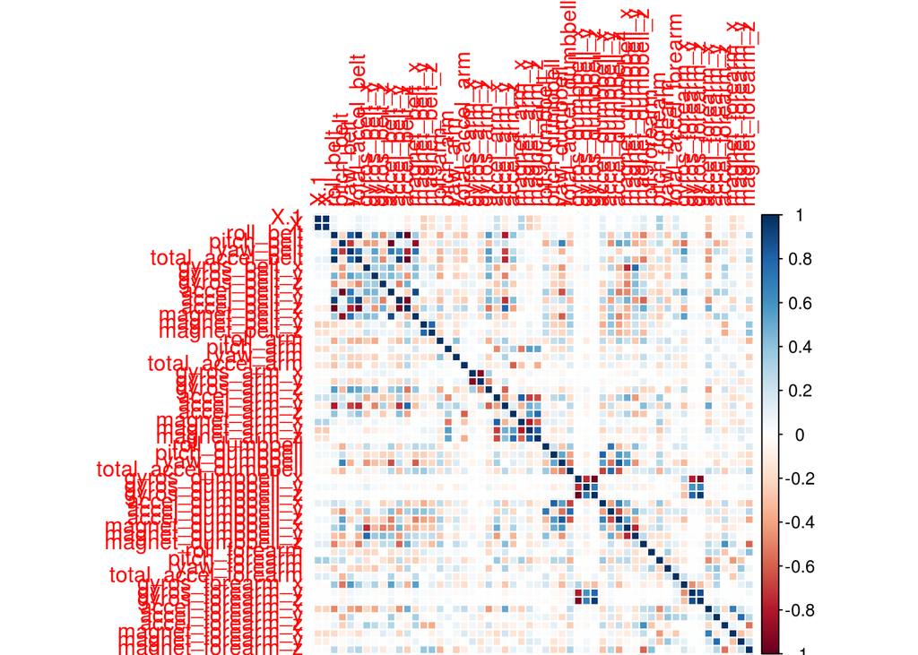

```r
corrplot(cor(training[, -which(classes==c("factor"))]), method="color")
```

There’s quite a bit of correlation.

let’s see our users

```r
table(training$user_name)
```

```
##
##   adelmo carlitos  charles   eurico   jeremy    pedro
##     2468     1976     2200     1916     2154     1652
```

6 users, around 2000 data points each.

```r
table(training$classe)
```

```
##
##    A    B    C    D    E
## 3516 2393 2157 2027 2273
```

5 classe types

Is one type of classe more common?

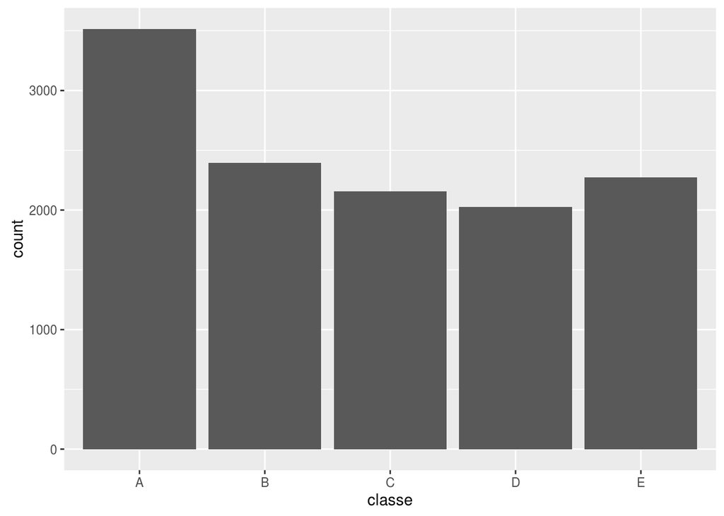

```r
df1 <- training %>% group_by(classe) %>% summarise(count = n())
ggplot(data = df1, aes(x=classe,y=count)) + geom_bar(stat = "identity")
```

A is the most common

Do some people do more of one type of exercise?

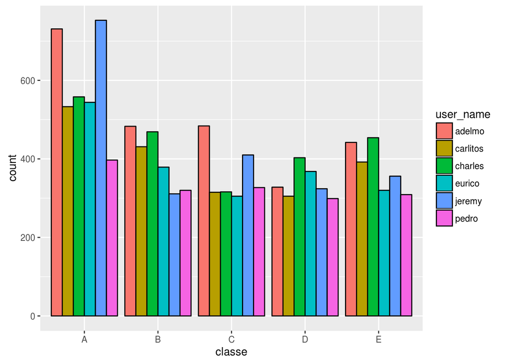

```r
df2 <- training %>% group_by(classe, user_name) %>% summarise(count = n())
ggplot(data = df2, aes(x=classe,y=count,fill=user_name)) +
    geom_bar(stat = "identity", position = "dodge", colour = "black") +
    scale_color_brewer()
```

### Predicting

Classe is a factor (category) so we should think about categorical classifiers.

Let’s try a tree model

```r
md1 <- train(classe ~ . , method = "rf", data = training, ntree = 10)
```

Let’s run it on the validation data.

```r
predict1 <- predict(md1,validation[,-which(names(validation)==c("classe"))])
confusionMatrix(validation$classe, predict1)
```

```
## Confusion Matrix and Statistics
##
##           Reference
## Prediction   A   B   C   D   E
##          A 390   0   0   0   0
##          B   0 265   0   0   0
##          C   0   0 239   0   0
##          D   0   0   0 225   0
##          E   0   0   0   0 252
##
## Overall Statistics
##
##                Accuracy : 1
##                  95% CI : (0.9973, 1)
##     No Information Rate : 0.2845
##     P-Value [Acc > NIR] : < 2.2e-16
##
##                   Kappa : 1
##  Mcnemar's Test P-Value : NA
##
## Statistics by Class:
##
##                      Class: A Class: B Class: C Class: D Class: E
## Sensitivity            1.0000   1.0000   1.0000   1.0000   1.0000
## Specificity            1.0000   1.0000   1.0000   1.0000   1.0000
## Pos Pred Value         1.0000   1.0000   1.0000   1.0000   1.0000
## Neg Pred Value         1.0000   1.0000   1.0000   1.0000   1.0000
## Prevalence             0.2845   0.1933   0.1743   0.1641   0.1838
## Detection Rate         0.2845   0.1933   0.1743   0.1641   0.1838
## Detection Prevalence   0.2845   0.1933   0.1743   0.1641   0.1838
## Balanced Accuracy      1.0000   1.0000   1.0000   1.0000   1.0000
```

The model performs very well on the validation data. Normally I would try a few different models and select the one that performed the best on the validation data, but there doesn’t seem to be a need.

Let’s run it on the test data.

```r
test <- read.csv("clean_test_data.csv")
predictTest <- predict(md1, test[,-which(names(test)==c("classe"))])
confusionMatrix(test$classe, predictTest)
```

```
## Confusion Matrix and Statistics
##
##           Reference
## Prediction    A    B    C    D    E
##          A 1674    0    0    0    0
##          B    1 1137    1    0    0
##          C    0    0 1026    0    0
##          D    0    0    0  964    0
##          E    0    0    0    0 1082
##
## Overall Statistics
##
##                Accuracy : 0.9997
##                  95% CI : (0.9988, 1)
##     No Information Rate : 0.2846
##     P-Value [Acc > NIR] : < 2.2e-16
##
##                   Kappa : 0.9996
##  Mcnemar's Test P-Value : NA
##
## Statistics by Class:
##
##                      Class: A Class: B Class: C Class: D Class: E
## Sensitivity            0.9994   1.0000   0.9990   1.0000   1.0000
## Specificity            1.0000   0.9996   1.0000   1.0000   1.0000
## Pos Pred Value         1.0000   0.9982   1.0000   1.0000   1.0000
## Neg Pred Value         0.9998   1.0000   0.9998   1.0000   1.0000
## Prevalence             0.2846   0.1932   0.1745   0.1638   0.1839
## Detection Rate         0.2845   0.1932   0.1743   0.1638   0.1839
## Detection Prevalence   0.2845   0.1935   0.1743   0.1638   0.1839
## Balanced Accuracy      0.9997   0.9998   0.9995   1.0000   1.0000
```

### Conclusion

This model using random forest is an extremely good fit with and accuracy of 99.97%. Only two observation out of 5885 of the test data was mis-clasified.